# Analyse AirBNB Dataset

### Dataset AirBNB advertenties Amsterdam juni 2016

## Inhoud

1. Data importeren, bekijken en opschonen
2. Omvang en omzet AirBNB markt Amsterdam
3. Divisie buurten Amsterdam & kaartweergave
4. Wat is de return on investment (ROI) van een woning die permanent verhuurd wordt via Airbnb?
5. Welke overtredingen van regels mbt verhuur vind je in de data? Om hoeveel euro gaat dit ongeveer?
6. Welke aanbeveling zou je aan de gemeente Amsterdam doen op basis van deze data? En welke aanbeveling aan verhuurders? En toeristen?

## 1. Data importeren, bekijken en opschonen

### 1.1 Data importeren en bekijken

```python
#Importen van de libraries
import pandas as pd
import numpy as np
import seaborn as sns
import matplotlib.pyplot as plt
%matplotlib inline
```

```python
#Inlezen van de data
data = pd.read_csv("data/listings.csv")
```

```python
#Data bekijken1
print(data.head(3),"\n")
print('Aantal rijen en kolommen: ', str(data.shape[0]) + ', ', data.shape[1])
```

```
         id                                               name   host_id  \
0   9784567                             nice Room in Amsterdam  27280608
1  13163805        Best cost benefit room near a metro station  35491461
2   3719167  Nice  room in A´dam SE near nature & heart centre  18991270

  host_name  neighbourhood_group neighbourhood   latitude  longitude  \
0     Petra                  NaN  Bijlmer-Oost  52.323369   4.977730
1   Phillip                  NaN  Bijlmer-Oost  52.315635   4.978166
2     Maria                  NaN  Bijlmer-Oost  52.316711   4.986618

      room_type  price  minimum_nights  number_of_reviews last_review  \
0  Private room     95               1                  5  2016-06-27
1  Private room     60               1                  4  2016-06-27
2  Private room     45               5                 11  2016-01-02

   reviews_per_month  calculated_host_listings_count  availability_365
0               0.81                               3               365
1               4.00                               1                77
2               0.48                               1                23

Aantal rijen en kolommen:  13849,  16
```

```python
#Data bekijken2
print(data.info())
```

```
<class 'pandas.core.frame.DataFrame'>
RangeIndex: 13849 entries, 0 to 13848
Data columns (total 16 columns):
id                                13849 non-null int64
name                              13849 non-null object
host_id                           13849 non-null int64
host_name                         13813 non-null object
neighbourhood_group               0 non-null float64
neighbourhood                     13849 non-null object
latitude                          13849 non-null float64
longitude                         13849 non-null float64
room_type                         13849 non-null object
price                             13849 non-null int64
minimum_nights                    13849 non-null int64
number_of_reviews                 13849 non-null int64
last_review                       11386 non-null object
reviews_per_month                 11386 non-null float64
calculated_host_listings_count    13849 non-null int64
availability_365                  13849 non-null int64
dtypes: float64(4), int64(7), object(5)
memory usage: 1.7+ MB
None
```

```python
#Data bekijken3
print(data.describe())
```

```
                 id       host_id  neighbourhood_group      latitude  \
count  1.384900e+04  1.384900e+04                  0.0  13849.000000
mean   7.414648e+06  2.210917e+07                  NaN     52.365568
std    4.226337e+06  2.119229e+07                  NaN      0.015315
min    2.818000e+03  3.159000e+03                  NaN     52.290402
25%    3.728983e+06  5.590622e+06                  NaN     52.355850
50%    7.555385e+06  1.402933e+07                  NaN     52.365208
75%    1.126592e+07  3.451633e+07                  NaN     52.374948
max    1.382844e+07  8.152423e+07                  NaN     52.428571

          longitude         price  minimum_nights  number_of_reviews  \
count  13849.000000  13849.000000    13849.000000       13849.000000
mean       4.889059    132.837100        2.933136          15.426457
std        0.034308    105.267487       11.166251          29.832918
min        4.763264     10.000000        1.000000           0.000000
25%        4.865537     89.000000        2.000000           1.000000
50%        4.886427    115.000000        2.000000           6.000000
75%        4.907372    150.000000        3.000000          16.000000
max        5.027689   8616.000000     1000.000000         416.000000

       reviews_per_month  calculated_host_listings_count  availability_365
count       11386.000000                    13849.000000      13849.000000
mean            1.426771                        6.254675        129.650444
std             1.412092                       22.764329        132.248811
min             0.020000                        1.000000          0.000000
25%             0.460000                        1.000000          6.000000
50%             0.990000                        1.000000         69.000000
75%             1.920000                        1.000000        259.000000
max            12.250000                      156.000000        365.000000
```

**Eerste observaties**  
• 13849 rijen en 16 kolommen  
• Kolom 'neighbourhood_group' heeft alleen NaN values  
• Kolom 'host_name' heeft 36 missende waardes  
• Kolommen 'last_review' and 'reviews_per_month' hebben ongeveer 2500 missende waardes  
• Kolom 'last_review' vertegenwoordigt een datum  
• Geografische locatie is vermeld met lengte- en breedtegraad

### 1.2 Dataset opschonen

#### 1.2.1 Verwijder kolom 'neighbourhood_group' & Converteer 'last_review' (type object) naar type datetime

```python
data = data.drop('neighbourhood_group', axis=1)
data['last_review'] = pd.to_datetime(data['last_review'])
```

#### 1.2.2 Controleer missende waardes van 'host_name'

```python
print('Aantal missende waardes in \'host_name\':', data[data['host_name'].isnull()]['host_name'].size)
data[data['host_name'].isnull()].sample(3)
```

```
Aantal missende waardes in 'host_name': 36
```

|  | id | name | host_id | host_name | neighbourhood | latitude | longitude | room_type | price | minimum_nights | number_of_reviews | last_review | reviews_per_month | calculated_host_listings_count | availability_365 |
| --- | --- | --- | --- | --- | --- | --- | --- | --- | --- | --- | --- | --- | --- | --- | --- |
| 10428 | 8714969 | Cozy apartment on the canal | 3466926 | NaN | De Baarsjes - Oud-West | 52.367832 | 4.871315 | Entire home/apt | 150 | 2 | 0 | NaT | NaN | 1 | 0 |
| 7540 | 11073680 | 55 m2 on famous Albert Cuyp market | 57486614 | NaN | De Pijp - Rivierenbuurt | 52.356775 | 4.898797 | Entire home/apt | 89 | 1 | 1 | 2016-02-22 | 0.22 | 1 | 0 |
| 13163 | 10227700 | Leuke Kamer | 52558016 | NaN | Bos en Lommer | 52.378448 | 4.857322 | Private room | 120 | 1 | 1 | 2015-12-29 | 0.16 | 1 | 0 |

#### 1.2.3 controleer de ~2500 missende waardes van 'last_review'

```python
data[data['last_review'].isnull()].sample(2)
```

|  | id | name | host_id | host_name | neighbourhood | latitude | longitude | room_type | price | minimum_nights | number_of_reviews | last_review | reviews_per_month | calculated_host_listings_count | availability_365 |
| --- | --- | --- | --- | --- | --- | --- | --- | --- | --- | --- | --- | --- | --- | --- | --- |
| 506 | 913470 | Family house with a garden (112m2) | 4903266 | Teun | Oud-Noord | 52.398538 | 4.917685 | Entire home/apt | 100 | 7 | 0 | NaT | NaN | 1 | 72 |
| 2706 | 6559031 | Bright spacious bedroom with sunny balcony | 8698376 | Stef | Centrum-West | 52.385535 | 4.884697 | Private room | 65 | 3 | 0 | NaT | NaN | 1 | 32 |

Elke advertentie in deze **sample** heeft waarde 0 bij 'number_of_reviews' en waarde NaN bij 'reviews_per_month'.

```python
#Controleer of alle advertenties zonder laatste review waarde 0 hebben bij 'aantal reviews' en geen waarde hebben bij 'reviews per maand'.
last_review_vs_number_of_reviews_check = (data[data['last_review'].isnull()].index == (data[data['number_of_reviews'] == 0].index)).all()
last_review_vs_reviews_per_month_check = (data[data['last_review'].isnull()].index == data[data['reviews_per_month'].isnull()].index).all()
print('last_review_NaT = number_of_reviews_0:', last_review_vs_number_of_reviews_check)
print('last_review_NaT = reviews_per_month_NaN:',last_review_vs_reviews_per_month_check)
```

```
last_review_NaT = number_of_reviews_0: True
last_review_NaT = reviews_per_month_NaN: True
```

```python
#Tel het aantal advertenties zonder reviews
ads_zonder_review = data['last_review'].isnull().sum()
print('Aantal advertenties zonder reviews en geen waarde bij \'laatste review\' en \'reviews per maand\':', ads_zonder_review)
```

```
Aantal advertenties zonder reviews en geen waarde bij 'laatste review' en 'reviews per maand': 2463
```

```python
#Converteer missende waardes in 'reviews_per_month' naar waarde 0
data.loc[data['reviews_per_month'].isnull(), 'reviews_per_month'] = 0
```

#### 1.2.4 Controle opschonen van de dataset

```python
data.sample(5)
```

|  | id | name | host_id | host_name | neighbourhood | latitude | longitude | room_type | price | minimum_nights | number_of_reviews | last_review | reviews_per_month | calculated_host_listings_count | availability_365 |
| --- | --- | --- | --- | --- | --- | --- | --- | --- | --- | --- | --- | --- | --- | --- | --- |
| 11907 | 9215970 | Z703 Totally redecorated room A'dam | 8543234 | Priscilla | De Baarsjes - Oud-West | 52.371237 | 4.864584 | Private room | 35 | 14 | 4 | 2016-03-24 | 0.53 | 28 | 341 |
| 9377 | 10244922 | ROOF TERRACE! Super appartment | 7002898 | Twan | Zuid | 52.352507 | 4.855867 | Entire home/apt | 110 | 2 | 14 | 2016-05-16 | 2.30 | 57 | 177 |
| 132 | 6484413 | NICE APARTMENT IN AMSTERDAM NORTH | 33887116 | John | Noord-Oost | 52.398475 | 4.945118 | Entire home/apt | 175 | 2 | 31 | 2016-05-15 | 2.34 | 1 | 353 |
| 5197 | 5401988 | Renovated apartment Upper East! | 8697755 | Pepijn | Oud-Oost | 52.355320 | 4.914844 | Entire home/apt | 95 | 2 | 21 | 2016-05-23 | 1.38 | 1 | 341 |
| 8371 | 12627198 | Happy 2 room RAI & Pijp | 68560773 | Martina | De Pijp - Rivierenbuurt | 52.343344 | 4.894409 | Entire home/apt | 80 | 2 | 6 | 2016-06-20 | 2.86 | 1 | 0 |

**Overzicht aanpassingen aan de dataset:**  
• Kolom 'neighbourhood_group' is verwijderd  
• Kolom 'last_review' is veranderd naar type datetime  
• Missende waardes in kolom 'reviews_per_month' zijn veranderd naar waarde 0

### 1.3 Inhoud van de kolommen

```python
#Unieke waardes per kolom
print('neighbourhood:\n', data.neighbourhood.unique(),'\n')
print('room_type:\n', data.room_type.unique())
```

```
neighbourhood:
 ['Bijlmer-Oost' 'Noord-Oost' 'Noord-West' 'Oud-Noord'
 'IJburg - Zeeburgereiland' 'Centrum-West'
 'Oostelijk Havengebied - Indische Buurt' 'Centrum-Oost' 'Oud-Oost'
 'Watergraafsmeer' 'Gaasperdam - Driemond' 'Westerpark' 'Bijlmer-Centrum'
 'De Pijp - Rivierenbuurt' 'Zuid' 'Buitenveldert - Zuidas'
 'De Baarsjes - Oud-West' 'Bos en Lommer' 'Geuzenveld - Slotermeer'
 'Slotervaart' 'Osdorp' 'De Aker - Nieuw Sloten']

room_type:
 ['Private room' 'Entire home/apt' 'Shared room']
```

```python
#Aantal unieke waardes per kolom
for col in data.columns:
    print(col + ":", data[col].unique().size)
```

```
id: 13849
name: 13408
host_id: 11464
host_name: 4441
neighbourhood: 22
latitude: 13849
longitude: 13849
room_type: 3
price: 329
minimum_nights: 47
number_of_reviews: 234
last_review: 586
reviews_per_month: 694
calculated_host_listings_count: 27
availability_365: 366
```

```python
#Bekijk de 5 meest voorkomende waardes per kolom
cols = ['host_id', 'host_name', 'neighbourhood','room_type']
for col in cols:
    print(col +':' + '\n' +  str(data[col].value_counts().head()),'\n')
```

```
host_id:
669178      156
6999042     128
1464510      98
48703385     71
7002898      57
Name: host_id, dtype: int64

host_name:
Sammy               156
Douwe&Niki          128
Michiel And Jane     98
Tillan               71
Anne                 70
Name: host_name, dtype: int64

neighbourhood:
De Baarsjes - Oud-West     2431
Centrum-West               1880
De Pijp - Rivierenbuurt    1624
Centrum-Oost               1346
Westerpark                 1029
Name: neighbourhood, dtype: int64

room_type:
Entire home/apt    11169
Private room        2609
Shared room           71
Name: room_type, dtype: int64
```

```python
#Bekijk de hoogste en laagste waardes per kolom
cols = ['price', 'minimum_nights', 'number_of_reviews', 'reviews_per_month']
for col in cols:
    print(col+':\n'+str(data[col].nlargest(2)),'\n'+str(data[col].nsmallest(2)),'\n')
```

```
price:
9395    8616
3266    1442
Name: price, dtype: int64
13666    10
7270     15
Name: price, dtype: int64

minimum_nights:
6987    1000
4150     523
Name: minimum_nights, dtype: int64
0    1
1    1
Name: minimum_nights, dtype: int64

number_of_reviews:
2124     416
12550    412
Name: number_of_reviews, dtype: int64
5     0
12    0
Name: number_of_reviews, dtype: int64

reviews_per_month:
690      12.25
13693    11.50
Name: reviews_per_month, dtype: float64
5     0.0
12    0.0
Name: reviews_per_month, dtype: float64
```

**Een aantal gegevens op een rij:**  
• Deze dataset bevat **13.849 AirBNB advertenties** in Amsterdam in juni 2016  
• **11.386 advertenties hebben één of meer een beoordelingen, 2463 advertenties hebben geen beoordeling**  
• Er zijn 11.464 unieke verhuurders  
• Een aantal van de verhuurder komt vaker dan één keer voor in de dataset, met als vaakst 156 keer  
• De advertenties zijn verdeeld in 22 buurten  
• Er worden drie soorten kamers aangeboden: 'Private room', 'Entire home/apt' en 'Shared room']  
• De prijs per overnachting varieerd van €10 tot €8.616  
• Het minimum aantal te boeken overnachtingen varieerd van 1 nacht tot 1000 nachten  
• **Het aantal beoordelingen per maand varieert van 0 tot 12.25**  
• Het aantal beoordelingen per advertentie loopt op tot 416

# 2. Omvang en omzet AirBNB markt Amsterdam

### 2.1 Omvang AirBNB markt Amsterdam

AirBNB advertenties: 13.849  
Gemiddeld aantal beoordeling per advertentie per maand: 1.173025¹  
Review rate: 50%²  
Gemiddeld aantal boekingen per advertentie per maand: 1.173025 / 0.5 ≈ 2.35  
Gemiddelde lengte van verblijf: 3.9 nachten³  
**Geschatte** aantal boekingen per maand in Amsterdam: 13.849 * 2.35 = **32.490**  
**Geschatte** aantal boekingen per jaar in Amsterdam: 32.490 * 12 = **389.880**  
**Geschatte** aantal overnachtingen per maand in Amsterdam: 32.490 * 3.9 = **126.711**  
**Geschatte** aantal overnachtingen per jaar in Amsterdam: 126.711*12 = **1.520.532**

1 data['reviews_per_month'].mean() --> 1.173025  
2 'Inside Airbnb's "San Francisco Model" uses a modified methodology as follows:  
A Review Rate of 50% is used to convert reviews to estimated bookings' - http://insideairbnb.com/about.html#disclaimers  
3 'Airbnb guests stay an average of **3.9 nights**' - https://www.airbnb.nl/press/news/new-study-airbnb-community-makes-amsterdam-economy-stronger

### 2.2 Omzet AirBNB markt Amsterdam

```python
#De omzet wordt berekend door een optelsom te maken van de prijs van elke advertentie vermenigvuldigd met
#het aantal reviews per maand, met 2 (review rate 50%) en met 3.9 (gemiddelde aantal overnachtingen per boeking)
omzet = sum(data['price'] * data['reviews_per_month'] * 2 * 3.9)
omzet_per_ad = omzet/data.shape[0]
omzet_per_ad_per_boeking = omzet_per_ad / data['reviews_per_month'].mean() /2
print('Geschatte omzet per maand totale AirBNB markt in Amsterdam: €' + str(round(omzet)).split('.')[0])
print('Geschatte omzet per advertentie per maand: €' + str(round(omzet_per_ad)).split('.')[0])
print('Geschatte omzet per advertentie per boeking: €' + str(round(omzet_per_ad_per_boeking)).split('.')[0])
print('\n'+ 'Geschatte omzet per jaar totale AirBNB markt in Amsterdam: €' + str(round(omzet*12)).split('.')[0])
```

```
Geschatte omzet per maand totale AirBNB markt in Amsterdam: €15318925
Geschatte omzet per advertentie per maand: €1106
Geschatte omzet per advertentie per boeking: €471

Geschatte omzet per jaar totale AirBNB markt in Amsterdam: €183827095
```

# 3. Divisie buurten Amsterdam & kaartweergave

### 3.1 Data groeperen per buurt

```python
#Groepeer de dataset per buurt en maak 3 lijsten met waardes (aantal advertenties, reviews per maand en boekingen per maand)
buurt_group = data.rename(columns={'neighbourhood':'Buurt'}).groupby(['Buurt'])
aantal_advertenties = buurt_group.size()
reviews_per_maand_per_ad = buurt_group.mean()['reviews_per_month']
boekingen_per_maand = aantal_advertenties * reviews_per_maand_per_ad * 2
```

```python
#Tabel met aantal advertenties, reviews per maand en boekingen per maand per buurt
tabel = pd.concat([aantal_advertenties, reviews_per_maand_per_ad, boekingen_per_maand], axis=1)
tabel.columns=['aantal_advertenties','reviews_per_maand_per_ad','boekingen_per_maand']
tabel = tabel.sort_values(by ='boekingen_per_maand', ascending=False)
tabel
```

| Buurt | aantal_advertenties | reviews_per_maand_per_ad | boekingen_per_maand |
| --- | --- | --- | --- |
| Centrum-West | 1880 | 1.463606 | 5503.16 |
| De Baarsjes - Oud-West | 2431 | 1.089412 | 5296.72 |
| De Pijp - Rivierenbuurt | 1624 | 1.140751 | 3705.16 |
| Centrum-Oost | 1346 | 1.376040 | 3704.30 |
| Westerpark | 1029 | 1.146054 | 2358.58 |
| Zuid | 1010 | 0.941832 | 1902.50 |
| Oud-Oost | 806 | 1.004938 | 1619.96 |
| Bos en Lommer | 695 | 1.062201 | 1476.46 |
| Oostelijk Havengebied - Indische Buurt | 694 | 0.917680 | 1273.74 |
| Oud-Noord | 391 | 1.189693 | 930.34 |
| Slotervaart | 280 | 1.198214 | 671.00 |
| Watergraafsmeer | 362 | 0.924530 | 669.36 |
| IJburg - Zeeburgereiland | 272 | 0.965441 | 525.20 |
| Noord-West | 186 | 1.411774 | 525.18 |
| Geuzenveld - Slotermeer | 138 | 1.444928 | 398.80 |
| Osdorp | 99 | 1.820303 | 360.42 |
| Buitenveldert - Zuidas | 160 | 1.087938 | 348.14 |
| Noord-Oost | 159 | 0.967484 | 307.66 |
| De Aker - Nieuw Sloten | 91 | 1.598022 | 290.84 |
| Bijlmer-Oost | 72 | 1.591806 | 229.22 |
| Bijlmer-Centrum | 61 | 1.617213 | 197.30 |
| Gaasperdam - Driemond | 63 | 1.558730 | 196.40 |

```python
#Voeg omzet per buurt, omzet per advertentie en omzet per boekingen toe aan de tabel
omzet_per_buurt = []
for buurt in tabel.index:
    omzet_per_buurt.append(str(sum(data[data['neighbourhood'] == buurt]['price'] *  data[data['neighbourhood'] == buurt]['reviews_per_month'] /0.5*3.9)).split('.')[0])
tabel['omzet_per_buurt'] = omzet_per_buurt
tabel['omzet_per_buurt'] = tabel['omzet_per_buurt'].astype('int')
tabel['omzet_per_ad_per_maand'] = round(tabel['omzet_per_buurt'] / tabel['aantal_advertenties'],2)
tabel['omzet_per_boeking'] = round(tabel['omzet_per_ad_per_maand']/tabel['reviews_per_maand_per_ad']/2,2)
tabel
```

| Buurt | aantal_advertenties | reviews_per_maand_per_ad | boekingen_per_maand | omzet_per_buurt | omzet_per_ad_per_maand | omzet_per_boeking |
| --- | --- | --- | --- | --- | --- | --- |
| Centrum-West | 1880 | 1.463606 | 5503.16 | 3222953 | 1714.34 | 585.66 |
| De Baarsjes - Oud-West | 2431 | 1.089412 | 5296.72 | 2441396 | 1004.28 | 460.93 |
| De Pijp - Rivierenbuurt | 1624 | 1.140751 | 3705.16 | 1760361 | 1083.97 | 475.11 |
| Centrum-Oost | 1346 | 1.376040 | 3704.30 | 2119719 | 1574.83 | 572.23 |
| Westerpark | 1029 | 1.146054 | 2358.58 | 1075198 | 1044.90 | 455.87 |
| Zuid | 1010 | 0.941832 | 1902.50 | 914401 | 905.35 | 480.63 |
| Oud-Oost | 806 | 1.004938 | 1619.96 | 705522 | 875.34 | 435.52 |
| Bos en Lommer | 695 | 1.062201 | 1476.46 | 530463 | 763.26 | 359.28 |
| Oostelijk Havengebied - Indische Buurt | 694 | 0.917680 | 1273.74 | 545117 | 785.47 | 427.97 |
| Oud-Noord | 391 | 1.189693 | 930.34 | 404595 | 1034.77 | 434.89 |
| Slotervaart | 280 | 1.198214 | 671.00 | 224921 | 803.29 | 335.20 |
| Watergraafsmeer | 362 | 0.924530 | 669.36 | 276905 | 764.93 | 413.69 |
| IJburg - Zeeburgereiland | 272 | 0.965441 | 525.20 | 217166 | 798.40 | 413.49 |
| Noord-West | 186 | 1.411774 | 525.18 | 166474 | 895.02 | 316.98 |
| Geuzenveld - Slotermeer | 138 | 1.444928 | 398.80 | 123885 | 897.72 | 310.65 |
| Osdorp | 99 | 1.820303 | 360.42 | 111570 | 1126.97 | 309.56 |
| Buitenveldert - Zuidas | 160 | 1.087938 | 348.14 | 126738 | 792.11 | 364.04 |
| Noord-Oost | 159 | 0.967484 | 307.66 | 100207 | 630.23 | 325.71 |
| De Aker - Nieuw Sloten | 91 | 1.598022 | 290.84 | 101200 | 1112.09 | 347.96 |
| Bijlmer-Oost | 72 | 1.591806 | 229.22 | 58078 | 806.64 | 253.37 |
| Bijlmer-Centrum | 61 | 1.617213 | 197.30 | 39579 | 648.84 | 200.60 |
| Gaasperdam - Driemond | 63 | 1.558730 | 196.40 | 52467 | 832.81 | 267.14 |

### 3.2 Geodata buurten Amsterdam importen en samenvoegen met AirBNB data

```python
#Importeer Geopandas
import geopandas as gpd
```

```python
#laad de shapefile van de 22 buurten in een dataframe en bekijk
sf = 'data/GEBIEDEN22_EXWATER.shp' #Bron: https://maps.amsterdam.nl/open_geodata/, 22 Gebieden excl.water
map_ams = gpd.read_file(sf)
map_ams.head()
```

|  | Gebied_cod | Gebied | Stadsdeel_ | Opp_m2 | FID | geometry |
| --- | --- | --- | --- | --- | --- | --- |
| 0 | DX20 | Bijlmer Centrum | T | 8431710 | 1 | POLYGON ((4.971847 52.284349, 4.971365 52.2840... |
| 1 | DX21 | Bijlmer Oost | T | 4076020 | 2 | POLYGON ((4.996904 52.31763, 4.995265 52.31678... |
| 2 | DX05 | Oud West / De Baarsjes | E | 3327090 | 3 | POLYGON ((4.882102 52.362043, 4.880608 52.3616... |
| 3 | DX07 | Osdorp | F | 9068100 | 4 | POLYGON ((4.80954 52.363504, 4.809187 52.36349... |
| 4 | DX13 | Oud Oost | M | 2118640 | 5 | POLYGON ((4.905406 52.359379, 4.90598 52.35948... |

De namen van de buurten in de shapefile van Amsterdam zijn anders dan die in de dataset AirBNB én de shapefile bevat één extra buurt.

```python
#Verander de namen van de buurten in map_ams naar de namen in de AirBNB dataset
map_ams['Gebied'] = map_ams['Gebied'].replace({'Bijlmer Centrum':'Bijlmer-Centrum', 'Bijlmer Oost':'Bijlmer-Oost', 'Oud West / De Baarsjes':'De Baarsjes - Oud-West', 'Osdorp':'Osdorp','Oud Oost':'Oud-Oost', 'Buitenveldert / Zuidas':'Buitenveldert - Zuidas',
'Noord Oost':'Noord-Oost', 'Gaasperdam / Driemond':'Gaasperdam - Driemond', 'De Pijp / Rivierenbuurt':'De Pijp - Rivierenbuurt', 'Geuzenveld-Slotermeer-Sloterdijken':'Geuzenveld - Slotermeer', 'Centrum-West':'Centrum-West', 'De Aker, Sloten en Nieuw Sloten':'De Aker - Nieuw Sloten', 'Noord West':'Noord-West', 'IJburg / Eiland Zeeburg':'IJburg - Zeeburgereiland', 'Slotervaart':'Slotervaart', 'Westerpark':'Westerpark', 'Indische Buurt / Oostelijk Havengebied':'Oostelijk Havengebied - Indische Buurt',
'Bos en Lommer':'Bos en Lommer', 'Oud Zuid':'Zuid', 'Watergraafsmeer':'Watergraafsmeer', 'Centrum-Oost':'Centrum-Oost', 'Oud Noord':'Oud-Noord'})
#'Westpoort' zit wel in de dataset map_ams, maar niet in de dataset airBNB.
# Verwijder rij 'Westpoort' uit de dataset map_ams
westpoort_index = map_ams[map_ams['Gebied']=='Westpoort'].index
map_ams = map_ams.drop(map_ams.index[westpoort_index])
```

```python
#Merge gegevens van de tabel met de gegevens van de shapefile
map_ams=pd.merge(left=map_ams,right=tabel,how='left',left_on='Gebied',right_on='Buurt')
map_ams.head()
```

|  | Gebied_cod | Gebied | Stadsdeel_ | Opp_m2 | FID | geometry | aantal_advertenties | reviews_per_maand_per_ad | boekingen_per_maand | omzet_per_buurt | omzet_per_ad_per_maand | omzet_per_boeking |
| --- | --- | --- | --- | --- | --- | --- | --- | --- | --- | --- | --- | --- |
| 0 | DX20 | Bijlmer-Centrum | T | 8431710 | 1 | POLYGON ((4.971847 52.284349, 4.971365 52.2840... | 61 | 1.617213 | 197.30 | 39579 | 648.84 | 200.60 |
| 1 | DX21 | Bijlmer-Oost | T | 4076020 | 2 | POLYGON ((4.996904 52.31763, 4.995265 52.31678... | 72 | 1.591806 | 229.22 | 58078 | 806.64 | 253.37 |
| 2 | DX05 | De Baarsjes - Oud-West | E | 3327090 | 3 | POLYGON ((4.882102 52.362043, 4.880608 52.3616... | 2431 | 1.089412 | 5296.72 | 2441396 | 1004.28 | 460.93 |
| 3 | DX07 | Osdorp | F | 9068100 | 4 | POLYGON ((4.80954 52.363504, 4.809187 52.36349... | 99 | 1.820303 | 360.42 | 111570 | 1126.97 | 309.56 |
| 4 | DX13 | Oud-Oost | M | 2118640 | 5 | POLYGON ((4.905406 52.359379, 4.90598 52.35948... | 806 | 1.004938 | 1619.96 | 705522 | 875.34 | 435.52 |

### 3.3 Plot de data op een kaart van Amsterdam

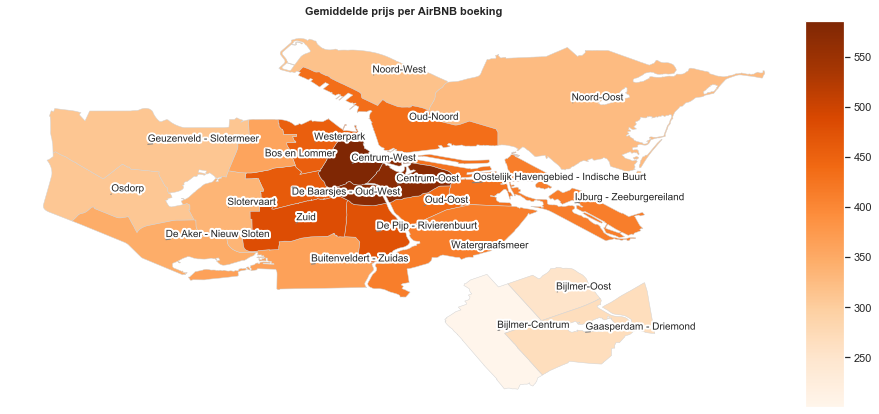

```python
from mpl_toolkits.axes_grid1 import make_axes_locatable
import matplotlib.patheffects as pe
import adjustText as aT

ax = map_ams.plot('omzet_per_boeking', cmap='Oranges', figsize = (15, 12), edgecolor = "lightgrey", linewidth = 0.5)
ax.axis('off')
ax.set_title('Gemiddelde prijs per AirBNB boeking', fontdict={'fontsize': '11', 'fontweight' : '800'})

#Plot buurtnamen
texts = []
for x, y, label in zip(map_ams.centroid.x, map_ams.centroid.y, map_ams["Gebied"]):
    texts.append(plt.text(x, y, label, fontsize = 10, path_effects=[pe.withStroke(linewidth=4, foreground="white")]))

#Trek buurtnamen uit elkaar (geen overlapping)
aT.adjust_text(texts, expand_text=(0.000001, 0.0001), arrowprops=dict(arrowstyle="-", color='gray', lw=1))

#Colorbar
divider = make_axes_locatable(ax)
cax = divider.append_axes("right", size="5%", pad=0.05)
sm = plt.cm.ScalarMappable(cmap='Oranges', norm=plt.Normalize(vmin=map_ams.omzet_per_boeking.min(), vmax=map_ams.omzet_per_boeking.max()))
sm._A = []
cbar = plt.colorbar(sm, cax=cax)

plt.show()
```

# 4. Wat is de return on investment (ROI) van een woning die permanent verhuurd wordt via Airbnb?

### 4.1 Scope ROI

De definitie van return on investment (ROI) is het rendement op een investering.  
ROI bevat twee componenten: 1) investeringen, 2) opbrengsten.  
Bij het component 'investeringen' is de grootste kostenpost de prijs van het hebben, of het huren van een appartement. Deze prijs hangt af van zaken zoals: locatie, omvang, type huis, staat van het huis, inrichting, onderhoud, etc.. De vraag is ook wat voor soorten huizen er op AirBNB worden aangeboden en hoe een potentieel te verhuren huis zich daartoe verhoudt.  
**Deze analyse beperkt zich tot de opbrengstzijde van de ROI: De omzet van AirBNB verhuur**  
Op basis van de omzet kan een potentiële verhuurder zelf inschatten wat zijn rendement is.

### 4.2 Conclusie 'Wat is de return on investment (ROI) van een woning die permanent verhuurd wordt via Airbnb?''

```python
#Tabel met relevante gegevens voor een potentiële verhuurder
opbrengst_tabel = tabel.copy()
opbrengst_tabel['reviews_per_maand_per_ad'] = opbrengst_tabel['reviews_per_maand_per_ad']*2
opbrengst_tabel = opbrengst_tabel.drop('boekingen_per_maand',axis=1)
opbrengst_tabel = opbrengst_tabel.rename(columns={'reviews_per_maand_per_ad':'aantal_boekingen','omzet_per_ad_per_maand':'omzet'})
opbrengst_tabel = opbrengst_tabel.drop('omzet_per_buurt',axis=1)
opbrengst_tabel['nachten_per_boeking'] = 3.9
opbrengst_tabel['prijs_per_nacht'] = round(opbrengst_tabel['omzet_per_boeking'] / opbrengst_tabel['nachten_per_boeking'],2)
opbrengst_tabel['verhuurnachten'] = round(opbrengst_tabel['aantal_boekingen'] * opbrengst_tabel['nachten_per_boeking'],2)
#Maak logische volgorde van de kolommen
opbrengst_tabel = opbrengst_tabel[['aantal_advertenties','aantal_boekingen','nachten_per_boeking','verhuurnachten', 'prijs_per_nacht','omzet_per_boeking','omzet']]
opbrengst_tabel['omzet_permanent_verhuren']=round(opbrengst_tabel['prijs_per_nacht'] * 365/12).astype('int') #aantal dagen in een maand
#Maak kolomnamen presenteerbaar
opbrengst_tabel.columns = opbrengst_tabel.columns.str.replace('_',' ').str.capitalize()
opbrengst_tabel = opbrengst_tabel.sort_values(by='Omzet permanent verhuren',ascending=False)
print('Een potentiële verhuurder kan op basis van de tabel op de volgende slide inschatten wat zijn ROI is. \nIn de laatste kolom is de omzet bij permanent verhuren weergegeven.')
```

```
Een potentiële verhuurder kan op basis van de tabel op de volgende slide inschatten wat zijn ROI is.
In de laatste kolom is de omzet bij permanent verhuren weergegeven.
```

```python
opbrengst_tabel
```

| Buurt | Aantal advertenties | Aantal boekingen | Nachten per boeking | Verhuurnachten | Prijs per nacht | Omzet per boeking | Omzet | Omzet permanent verhuren |
| --- | --- | --- | --- | --- | --- | --- | --- | --- |
| Centrum-West | 1880 | 2.927213 | 3.9 | 11.42 | 150.17 | 585.66 | 1714.34 | 4568 |
| Centrum-Oost | 1346 | 2.752080 | 3.9 | 10.73 | 146.73 | 572.23 | 1574.83 | 4463 |
| Zuid | 1010 | 1.883663 | 3.9 | 7.35 | 123.24 | 480.63 | 905.35 | 3749 |
| De Pijp - Rivierenbuurt | 1624 | 2.281502 | 3.9 | 8.90 | 121.82 | 475.11 | 1083.97 | 3705 |
| De Baarsjes - Oud-West | 2431 | 2.178824 | 3.9 | 8.50 | 118.19 | 460.93 | 1004.28 | 3595 |
| Westerpark | 1029 | 2.292109 | 3.9 | 8.94 | 116.89 | 455.87 | 1044.90 | 3555 |
| Oud-Oost | 806 | 2.009876 | 3.9 | 7.84 | 111.67 | 435.52 | 875.34 | 3397 |
| Oud-Noord | 391 | 2.379386 | 3.9 | 9.28 | 111.51 | 434.89 | 1034.77 | 3392 |
| Oostelijk Havengebied - Indische Buurt | 694 | 1.835360 | 3.9 | 7.16 | 109.74 | 427.97 | 785.47 | 3338 |
| Watergraafsmeer | 362 | 1.849061 | 3.9 | 7.21 | 106.07 | 413.69 | 764.93 | 3226 |
| IJburg - Zeeburgereiland | 272 | 1.930882 | 3.9 | 7.53 | 106.02 | 413.49 | 798.40 | 3225 |
| Buitenveldert - Zuidas | 160 | 2.175875 | 3.9 | 8.49 | 93.34 | 364.04 | 792.11 | 2839 |
| Bos en Lommer | 695 | 2.124403 | 3.9 | 8.29 | 92.12 | 359.28 | 763.26 | 2802 |
| De Aker - Nieuw Sloten | 91 | 3.196044 | 3.9 | 12.46 | 89.22 | 347.96 | 1112.09 | 2714 |
| Slotervaart | 280 | 2.396429 | 3.9 | 9.35 | 85.95 | 335.20 | 803.29 | 2614 |
| Noord-Oost | 159 | 1.934969 | 3.9 | 7.55 | 83.52 | 325.71 | 630.23 | 2540 |
| Noord-West | 186 | 2.823548 | 3.9 | 11.01 | 81.28 | 316.98 | 895.02 | 2472 |
| Geuzenveld - Slotermeer | 138 | 2.889855 | 3.9 | 11.27 | 79.65 | 310.65 | 897.72 | 2423 |
| Osdorp | 99 | 3.640606 | 3.9 | 14.20 | 79.37 | 309.56 | 1126.97 | 2414 |
| Gaasperdam - Driemond | 63 | 3.117460 | 3.9 | 12.16 | 68.50 | 267.14 | 832.81 | 2084 |
| Bijlmer-Oost | 72 | 3.183611 | 3.9 | 12.42 | 64.97 | 253.37 | 806.64 | 1976 |
| Bijlmer-Centrum | 61 | 3.234426 | 3.9 | 12.61 | 51.44 | 200.60 | 648.84 | 1565 |

# 5. Welke overtredingen van regels mbt verhuur vind je in de data? Om hoeveel euro gaat dit ongeveer?

### 5.1 Regels voor AirBNB verhuurders in Amsterdam in 2016

**Verhuur volledig appartement:**  
• Maximaal aantal verhuurdagen: 60  
• Maximaal aantal huurders per boeking: 4  
• Toeristenbelasting 5%  
• Vakantieverhuur van een sociale huurwoning is verboden  
• Je bent hoofdbewoner, m.a.w. je woont ook daadwerkelijk op dit adres

**Verhuur kamer:**  
• Maximaal aantal verhuurdagen: geen  
• Maximaal aantal huurders per boeking: 4  
• Toeristenbelasting 5%  
• Je bent hoofdbewoner, m.a.w. je woont ook daadwerkelijk op dit adres

### 5.2 potentiële overtreders

Op basis van deze regels kunnen twee categorieën potentiële overtreders worden gedefinieerd:  
**1) Adverteerders die meer dan 60 dagen per jaar een volledig appartement verhuren.**  
2) Adverteerders die een niet-eigen-woning/kamer verhuren. De grootschalige overtreders in deze categorie zitten ook in de categorie 'meer dan 60 dagen per jaar verhuren'.

De analyse richt zich op de grootschalige overtreders: categorie 1  
Potentiële overtreders die een niet-eigen-woning/kamer verhuren worden in deze analyse buiten beschouwing gelaten.  
Ter vergelijking van het aanbod per type woning is onderstaande figuur weergegeven.

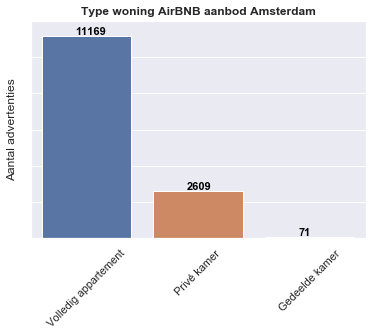

```python
ax=sns.barplot(x=data['room_type'].value_counts().index,y=data['room_type'].value_counts())
sns.set_style("darkgrid")
sns.set(rc={'figure.figsize':(8,6)})
ax.set_title('Type woning AirBNB aanbod Amsterdam',fontsize=12, weight='bold' )
ax.set_xlabel('')
ax.set_ylabel('Aantal advertenties')
ax.set_xticklabels(['Volledig appartement','Privé kamer','Gedeelde kamer'], rotation=45)
ax.set_yticklabels("")
ax.set_ylim(0,12000)
#plot het aantal boven de bars
for i in ax.patches:
    ax.text(i.get_x()+0.3, i.get_height()+100, str(round((int(i.get_height())), 2)), fontsize=11, color='black', weight='bold')
plt.show()
```

### 5.3 Verhuurders die meer dan 60 dagen per jaar een volledig appartement verhuren

Een overzicht van de overtreders in deze categorie kan worden berekend in twee stappen:  
1) Met het **aantal reviews** en het **aantal reviews per maand** wordt berekend hoe lang de advertentie al online staat en wat de plaatsingsdatum is.  
2) Met het **aantal reviews per maand** en de **gemiddelde lengte van een verblijf** wordt geschat of een advertentie het limiet van 60 dagen verhuren per jaar overschrijdt.

```python
#Voeg kolom toe met plaatsingsdatum per advertentie
import datetime
data['creation_date'] = pd.to_datetime('2016-07-04') - pd.to_timedelta(data['number_of_reviews'] / data['reviews_per_month'] * 30, unit='d')
data['creation_date'] = data['creation_date'].dt.strftime('%Y-%m-%d')
```

```python
#Voeg kolom toe met geschatte aantal verhuurdagen per advertentie per jaar en zet op max 365 dagen
data['est_yearly_rent_days'] = round(data['reviews_per_month'] * 2 * 12 *3.9).astype('int') #Review rate: 50%, nachten per boeking: 3.9
data.loc[data['est_yearly_rent_days']>365,'est_yearly_rent_days'] = 365
```

```python
data.sample(7)
```

|  | id | name | host_id | host_name | neighbourhood | latitude | longitude | room_type | price | minimum_nights | number_of_reviews | last_review | reviews_per_month | calculated_host_listings_count | availability_365 | creation_date | est_yearly_rent_days |
| --- | --- | --- | --- | --- | --- | --- | --- | --- | --- | --- | --- | --- | --- | --- | --- | --- | --- |
| 13153 | 10817774 | Bright & quiet flat with a terrace | 392580 | Anaïs | Bos en Lommer | 52.376487 | 4.855547 | Entire home/apt | 146 | 1 | 5 | 2016-06-25 | 2.31 | 1 | 15 | 2016-04-30 | 216 |
| 647 | 6340144 | Family house in Amsterdam | 33016739 | Jan Hein | Oud-Noord | 52.387110 | 4.945237 | Entire home/apt | 200 | 3 | 1 | 2016-06-27 | 1.00 | 1 | 14 | 2016-06-04 | 94 |
| 12012 | 6396889 | Appartement nearby Vondelpark | 7945947 | Sam | De Baarsjes - Oud-West | 52.358830 | 4.860997 | Entire home/apt | 226 | 1 | 1 | 2016-06-21 | 1.00 | 1 | 19 | 2016-06-04 | 94 |
| 7779 | 6971212 | Modern studio with TOP location | 4782603 | Yolande | De Pijp - Rivierenbuurt | 52.353878 | 4.893529 | Entire home/apt | 149 | 2 | 21 | 2016-06-26 | 1.73 | 1 | 29 | 2015-07-05 | 162 |
| 6019 | 8043141 | Top Floor Amsterdam east | 42469015 | Tom | Watergraafsmeer | 52.358121 | 4.943083 | Private room | 75 | 3 | 31 | 2016-06-21 | 3.11 | 1 | 290 | 2015-09-08 | 291 |
| 1594 | 10644438 | Romantic studio in heart of Jordaan | 52628502 | Jorrit | Centrum-West | 52.380634 | 4.886344 | Entire home/apt | 89 | 2 | 29 | 2016-06-27 | 5.69 | 2 | 326 | 2016-02-02 | 365 |
| 8231 | 12236947 | Romantic and cosy ap @ great spot! | 26799593 | Tamara | De Pijp - Rivierenbuurt | 52.355191 | 4.897186 | Entire home/apt | 120 | 3 | 0 | NaT | 0.00 | 1 | 0 | NaT | 0 |

#### 5.3.1 Aantal potentiële overtreders die meer dan 60 dagen per jaar verhuren

```python
#dataset van potentiële overtreders in categorie 1
potentiele_overtreders = data[(data['room_type']=='Entire home/apt') & (data['est_yearly_rent_days']>60)]
print('Aantal volledige appartementen die potentieel langer dan 60 dagen per jaar verhuurd worden:', potentiele_overtreders.shape[0])
print('Aantal potentiële overtreders in deze categorie:', len(potentiele_overtreders.host_id.unique()))
```

```
Aantal volledige appartementen die potentieel langer dan 60 dagen per jaar verhuurd worden: 5665
Aantal potentiële overtreders in deze categorie: 4946
```

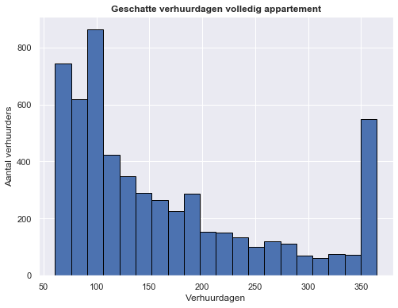

```python
#plot geschatte verhuurdagen per advertentie
fig, ax = plt.subplots(figsize=(8,6))
ax.hist(potentiele_overtreders.est_yearly_rent_days,rwidth=1, edgecolor='black',bins=20)
plt.title('Geschatte verhuurdagen volledig appartement', fontdict={'fontweight':'550'})
plt.xlabel('Verhuurdagen')
plt.ylabel('Aantal verhuurders')
plt.show()
```

#### 5.3.2 Omzet boven 60 dagen per jaar verhuren

```python
omzet_boven_60_dagen = sum((potentiele_overtreders['est_yearly_rent_days'] - 60) * potentiele_overtreders['price'])
print('Omzet boven 60 dagen: €' + str(omzet_boven_60_dagen))
```

```
Omzet boven 60 dagen: €80670907
```

```python
percentage_overtreding = omzet_boven_60_dagen/(omzet*12)*100
print('Geschatte omzet per jaar totale AirBNB markt in Amsterdam: €' + str(round(omzet*12)).split('.')[0])
print('Geschatte omzet per jaar in overtreding 60 dagen regel: €' + str(omzet_boven_60_dagen) +
      ' (' + str(round(percentage_overtreding,2)) +'%)')
```

```
Geschatte omzet per jaar totale AirBNB markt in Amsterdam: €183827095
Geschatte omzet per jaar in overtreding 60 dagen regel: €80670907 (43.88%)
```

### 5.4 Conclusie 'Welke overtredingen van regels mbt verhuur vind je in de data? Om hoeveel euro gaat dit ongeveer?'

**Verhuurders die meer dan 60 dagen per jaar een volledig appartement verhuren**  
Aantal volledige appartementen die potentieel langer dan 60 dagen per jaar verhuurd worden: 5.665  
Aantal potentiële overtreders in deze categorie: 4.946  
Geschatte omzet per jaar in overtreding 60 dagen regel: €80.670.907 (43.88% van de totale AirBNB omzet van Amsterdam)

**Verhuurders die een niet-eigen-woning/kamer verhuren**  
Buiten beschouwing in deze analyse

# 6. Welke aanbeveling zou je aan de gemeente Amsterdam doen op basis van deze data? En welke aanbeveling aan verhuurders? En toeristen?

### 6.1 aanbeveling gemeente Amsterdam

Als bestuurlijk orgaan voert de gemeente Amsterdam belangrijke taken uit in Amsterdam. Daarbij horen taken in de gebieden van toerisme, economische zaken, openbare orde en veiligheid, huisvesting en wet- en regelgeving. Aangezien er jaarlijks enorm veel toeristen naar Amsterdam komen is vakantieverhuur zoals via AirBNB een groot onderwerp en is het van belang goed beleid te voeren. Deze dataset en de analyse daarvan kan de gemeente helpen op de volgende manieren:  
• De omvang en de opbrengsten van de AirBNB markt inzichtelijk maken  
• Overtreders van regels in kaart brengen  
• Kansen en risico's identificeren

#### 6.1.1 De omvang en de opbrengsten van de AirBNB markt inzichtelijk maken

Geschatte aantal boekingen per jaar in Amsterdam: **390.000**  
Geschatte aantal overnachtingen per jaar in Amsterdam: **1.5 miljoen**  
Geschatte omzet per jaar totale AirBNB markt in Amsterdam: **€184 miljoen**

#### 6.1.2 Overtreders van regels in kaart brengen.

Aantal volledige appartementen dat potentieel langer dan 60 dagen per jaar verhuurd wordt: 5665  
Aantal potentiële overtreders die meer dan 60 dagen per jaar verhuren: 4946  
De regel 'alleen eigen woning verhuren' wordt ook in vele gevallen overtreden. De overtreders in deze categorie kunnen worden opgespoord met een gefilterde dataset en vervolgens per individueel geval nagaan of de regel wordt overtreden.

#### 6.1.3.1 Kansen

Verhuurders op AirBNB dienen een toeristenbelasting van 5% af te dragen. Dit kan veel geld opleveren voor de gemeente. Het advies is om drijfveren, al dan niet met boetes, te creëren om verhuurders aan te sporen hun AirBNB opbrengst aan te geven. Het resultaat hiervan kan oplopen tot €9.2 miljoen per jaar.

#### 6.1.3.2 Risico's

De data laat zien dat de meeste AirBNB verhuren in de binnenstad plaatsvinden. Veel Amsterdammers zeggen dat juist daar het te druk is, te veel toeristen zijn en te veel overlast is. Aan de andere kan is het begrijpelijk dat toeristen in de binnenstad willen huren. Het advies is om een limiet van verhuurders per gebied te onderzoeken.

### 6.2 aanbeveling verhuurders

• Verhuur enkel een kamer in het appartement. In dat geval hoef je niet te voldoen aan de regel 'maximaal 60 dagen per jaar verhuren'.  
• Verhuur je toch je hele woning, zorg dan dat je niet te veel reviews krijgt en/of verhuur met meerdere accounts.  
• Heb nooit meer dan één advertentie per account online staan.

### 6.3 aanbeveling toeristen

• Wil je een centrale locatie en ben je bereidt meer te betalen, huur dan in Centrum-West, Centrum-Oost, De Baarsjes - Oud-West of De Pijp - Rivierenbuurt.  
• Wil je minder betalen en toch in de buurt van het centrum huren, huur dan in Bos en Lommer.  
• Wil je zo goedkoop mogelijk, huur dan in Bijlmer-Centrum.